# TCR repertoire analysis with immunarch

Maria S. Benítez-Cantos, Carlos Cano, Armando Blanco

29-06-2020

I am following this [tutorial](https://immunarch.com/articles/v1_introduction.html). There are more sections that I ommited here.

# 1 Load data

## 1.1 Metadata

In other cases you may want to provide a metadata file and locate it in the folder. It is necessary to name it exactly "metadata.txt". The metadata file “metadata.txt” has to be tab delimited file with first column named “Sample” and any number of additional columns with arbitrary names. The first column should contain base names of files without extensions in your folder.

Creating the metadata.txt file:

|  | Sample | Patient | Tissue |
| --- | --- | --- | --- |
| 1 | 106H | 106 | H |
| 2 | 106L | 106 | L |
| 3 | 106S | 106 | S |
| 4 | 106V | 106 | V |
| 5 | 107H | 107 | H |
| 6 | 107L | 107 | L |
| 7 | 107S | 107 | S |
| 8 | 107V | 107 | V |
| 9 | 109H | 109 | H |
| 10 | 109L | 109 | L |

[output cut: 22 more lines]

## 1.2 Data

RTCR output files are in in AIRR format, readable by immunarch.

```
##
## == Step 1/3: loading repertoire files... ==
```

```
## Processing "input_immunarch/" ...
```

[output not shown]

# 2 Number of clonotypes

**About statistical tests:** *If data is grouped, than statistical tests for comparing means of groups will be performed, unless .test = F is supplied. In case there are only two groups, the **Wilcoxon rank** sum test is performed (R function wilcox.test with an argument exact = F) for testing if there is a difference in mean rank values between two groups. In case there more than two groups, the **Kruskal-Wallis** test is performed (R function kruskal.test), that is equivalent to ANOVA for ranks and it tests whether samples from different groups originated from the same distribution. A significant Kruskal-Wallis test indicates that at least one sample stochastically dominates one other sample. Adjusted for multiple comparisons P-values are plotted on the top of groups. P-value adjusting is done using the Holm method (also known as **Holm-Bonferroni** correction).*

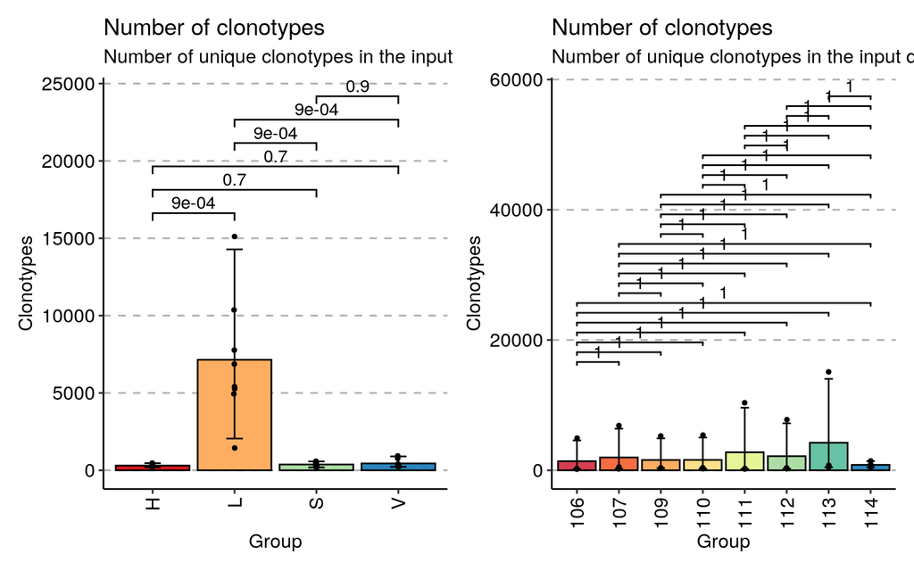

# 3 Repertoire overlap

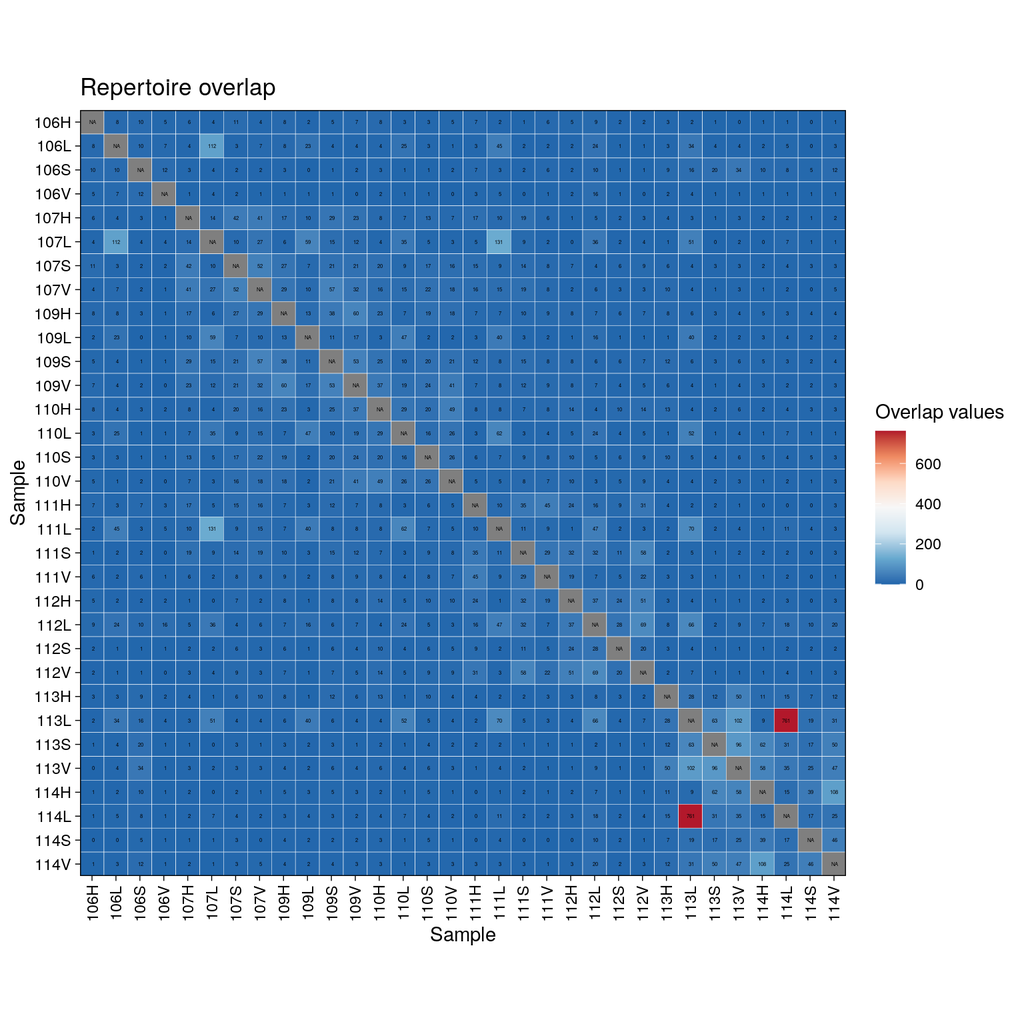

# 4 Diversity estimation

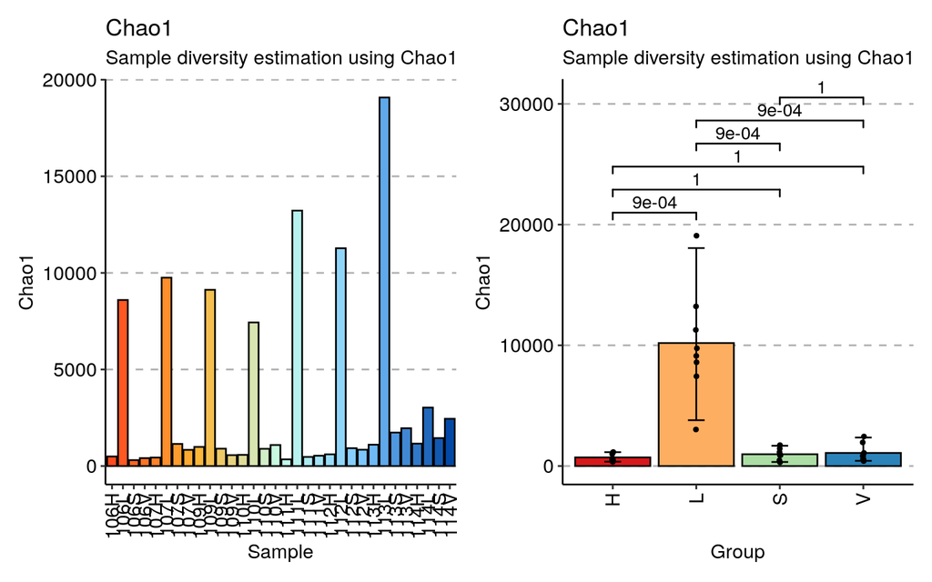